# Five classed MLWAM

William Lidberg

2020 M09 2

Load packages

```r
library(caret)
library(raster)
library(rgdal)
library(doParallel)
library(ggplot2)
library(xgboost)
```

Load training data

```r
OriginalDataNumeric<-read.table("V:/XGBoostArticle/TrainingData/XGBoostTrainingData.txt",  stringsAsFactors=FALSE, header = TRUE, dec = ",")
OriginalDataNumeric<-na.omit(OriginalDataNumeric)

#Set moisture label to factor
OriginalData<-OriginalDataNumeric
colsF <- c("Markfuktig","soil","wetlands")
OriginalData[colsF]<- lapply(OriginalData[colsF], factor)
str(OriginalData)
```

```
## 'data.frame':    19647 obs. of  25 variables:
##  $ dtw1      : num  0.259 0.309 0 0.02 0.115 ...
##  $ dtw5      : num  0.507 1.098 0.974 0.02 1.763 ...
##  $ dtw30     : num  0.507 6.4 6.098 0.02 1.763 ...
##  $ stdv5     : num  0.0935 0.0761 0.0337 0.0665 0.0581 ...
##  $ Winter    : num  70.7 106.3 106.3 98.5 91 ...
##  $ Summer    : num  13.4 17.2 17.2 20.2 20.3 ...
##  $ Autum     : num  12.8 25.9 25.9 21.2 22.9 ...
##  $ dtw05     : num  0.2732 0.2821 0.0248 0.0168 0.1327 ...
##  $ wetlands  : Factor w/ 2 levels "0","1": 1 1 1 1 1 1 1 2 2 1 ...
##  $ di2       : int  713 531 1573 2630 399 354 11 1683 94 63 ...
##  $ soil      : Factor w/ 7 levels "50","75","86",..: 1 1 1 1 1 2 5 2 5 3 ...
##  $ coordy    : int  6138147 6143736 6143715 6143456 6143777 6148381 6148380 6148104 6148401 6153358 ...
##  $ coordx    : int  377496 427687 427401 427691 432399 397647 397364 397644 422644 397314 ...
##  $ TWI24m    : num  7.78 6.5 9.82 10.45 9.26 ...
##  $ TWI48m    : num  9.51 9.31 10.85 10.1 9.73 ...
##  $ Markfuktig: Factor w/ 5 levels "1","2","3","4",..: 3 2 2 2 2 3 2 3 2 2 ...
##  $ CVA       : num  0.881 0.411 0.547 0.506 0.789 ...
##  $ DFME      : num  -0.42607 0.95581 0.00657 -0.52507 -1.56339 ...
##  $ Rugged    : num  0.0472 0.0609 0.0379 0.0357 0.0553 ...
##  $ SDFS      : num  0.642 0.926 0.705 0.421 0.594 ...
##  $ SoilDepth : num  10.7 15.6 15.6 19.5 23 ...
##  $ TWI10m    : int  7 7 8 11 13 8 6 8 8 9 ...
##  $ dtw2      : num  0.512 0.284 0 0 1.098 ...
##  $ Elevation : num  0.801 3.966 3.904 2.628 3.409 ...
##  $ Slope     : num  1.483 1.791 0.713 1.053 0.855 ...
```

Rename markfukt to quinaryMoisture for consistency

```r
# five classed data
quinaryMoisture<- OriginalDataNumeric$Markfuktig
quinarydataset<-cbind(OriginalData,quinaryMoisture)
quinarydataset$Markfuktig<-NULL
colF <- c("quinaryMoisture")
quinarydataset[colF]<- lapply(quinarydataset[colF], factor)
```

split data into training data 80 % and test data 20 %.

```r
set.seed(42)
#split five classed dataset
quinaryTrainingDataIndex<- createDataPartition(quinarydataset$quinaryMoisture, p=0.8, list = FALSE)
quinarytrainingData <- quinarydataset[quinaryTrainingDataIndex,]
quinarytestData <- quinarydataset[-quinaryTrainingDataIndex,]
```

Start by tuning max depth and learning rate (eta) while leaving everything else as default. Learning rate controls how much information from a new tree will be used in the Boosting. If it is close to zero we will use only a small piece of information from each new tree. If we set eta to 1 we will use all information from the new tree. Big values of eta result in a faster convergence and more over-fitting problems. Small values may need to many trees to converge.

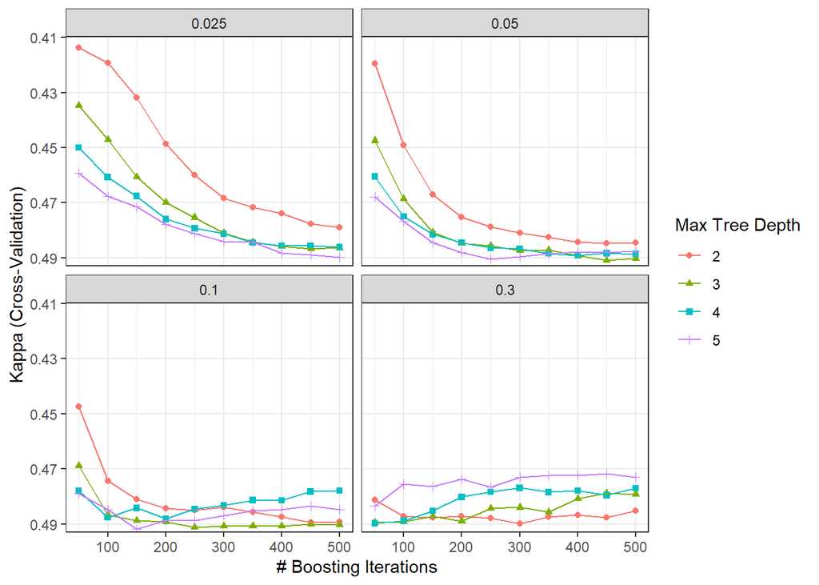

```r
set.seed(42)

#Tune grid
XGBoostgrid1 = expand.grid(
  nrounds = seq(from = 50, to = 500, by = 50),
  max_depth = c(2,3,4,5),
  eta = c(0.025, 0.05, 0.1, 0.3),
  gamma = c(0),
  colsample_bytree = c(1),
  min_child_weight = c(1),
  rate_drop = c(0),
  skip_drop = c(0),
  subsample = c(1)
)

#Ten fold cross validation will be used for tuning
tune_control <- caret::trainControl(method = "cv", number = 10, verboseIter = FALSE, allowParallel = TRUE)

xgbDARTtuningmodel5classes <- caret::train(quinaryMoisture~., data = quinarytrainingData, trControl = tune_control, tuneGrid = XGBoostgrid1, method = "xgbDART",verbose = TRUE, metric="Kappa")

# helper function for the plots
tuneplot <- function(x, probs = .90) {
  ggplot(x) +
    coord_cartesian(ylim = c(quantile(x$results$Kappa, probs = probs), min(x$results$Kappa))) +
    theme_bw()
}

tuneplot(xgbDARTtuningmodel5classes)
```

We will keep testing some values for max depth around the optimal while we tune rate drop and skip drop. Dropout value is a fraction of previous trees to drop during the dropout. If a dropout is skipped, new trees are added in the same manner as gbtree. If all trees are dropped the model is no different than random forest.

```r
set.seed(42)
XGBoostgrid2 <- expand.grid(
  nrounds = seq(from = 50, to = 500, by = 50),
  eta = xgbDARTtuningmodel5classes$bestTune$eta,
  max_depth = c(xgbDARTtuningmodel5classes$bestTune$max_depth - 1, xgbDARTtuningmodel5classes$bestTune$max_depth, xgbDARTtuningmodel5classes$bestTune$max_depth + 1),
  gamma = 0,
  colsample_bytree = 1,
  min_child_weight = c(1),
  rate_drop = c(0,0.25,0.5,0.75,1),
  skip_drop = c(0,0.25,0.5,0.75,1),
  subsample = c(1)
)

xgbDARTtuningmodel5classes2 <- caret::train(quinaryMoisture~., data = quinarytrainingData, trControl = tune_control, tuneGrid = XGBoostgrid2, method = "xgbDART",verbose = TRUE, metric="Kappa")
xgbDARTtuningmodel5classes2$bestTune
```

```
##     nrounds max_depth eta gamma subsample colsample_bytree rate_drop skip_drop
## 325     250         5 0.1     0         1                1      0.25       0.5
##     min_child_weight
## 325                1
```

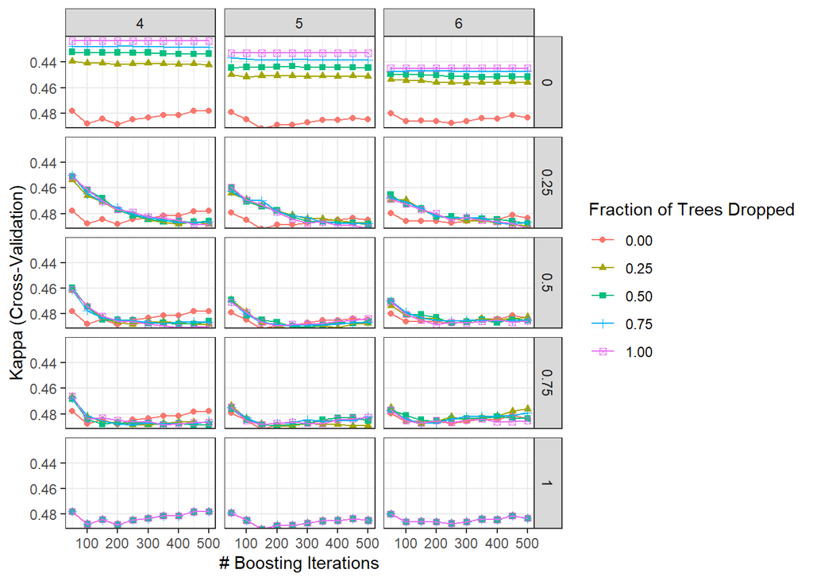

```r
tuneplot(xgbDARTtuningmodel5classes2)
```

Tune Column and Row Sampling. Subsampling occurs once for every tree constructed.

```r
XGBoostgrid3 <- expand.grid(
  nrounds = seq(from = 50, to = 500, by = 50),
  eta = xgbDARTtuningmodel5classes$bestTune$eta,
  max_depth = xgbDARTtuningmodel5classes2$bestTune$max_depth,
  gamma = 0,
  colsample_bytree = c(0.5, 0.75, 1.0),
  min_child_weight = c(1),
  rate_drop = xgbDARTtuningmodel5classes2$bestTune$rate_drop,
  skip_drop = xgbDARTtuningmodel5classes2$bestTune$skip_drop,
  subsample = c(0.5, 0.75, 1.0)
)

xgbDARTtuningmodel5classes3 <- caret::train(quinaryMoisture~., data = quinarytrainingData, trControl = tune_control, tuneGrid = XGBoostgrid3, method = "xgbDART",verbose = TRUE, metric="Kappa")

xgbDARTtuningmodel5classes3$bestTune
```

```
##   nrounds max_depth eta gamma subsample colsample_bytree rate_drop skip_drop
## 5     250         5 0.1     0       0.5              0.5      0.25       0.5
##   min_child_weight
## 5                1
```

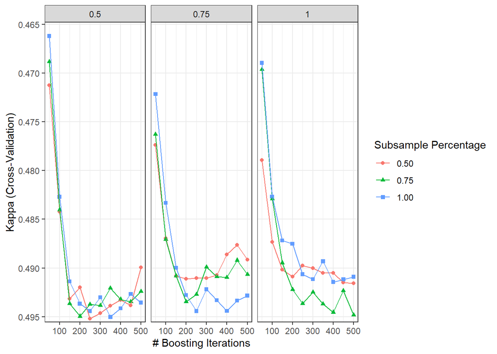

```r
tuneplot(xgbDARTtuningmodel5classes3)
```

min_child_weigth Controls the minimum number of observations (instances) in a terminal node. The minimum value for this parameter is 1, which allows the tree to have terminal nodes with only one observation. If we use bigger values we limit a possible perfect fit on some observations.

```r
set.seed(42)

XGBoostgrid4 <- expand.grid(
  nrounds = seq(from = 50, to = 500, by = 50),
  eta = xgbDARTtuningmodel5classes$bestTune$eta,
  max_depth = xgbDARTtuningmodel5classes2$bestTune$max_depth,
  gamma = 0,
  colsample_bytree = xgbDARTtuningmodel5classes3$bestTune$colsample_bytree,
  min_child_weight = c(1, 2, 3),
  rate_drop = xgbDARTtuningmodel5classes2$bestTune$rate_drop,
  skip_drop = xgbDARTtuningmodel5classes2$bestTune$skip_drop,
  subsample = xgbDARTtuningmodel5classes3$bestTune$subsample)

xgbDARTtuningmodel5classes4 <- caret::train(quinaryMoisture~., data = quinarytrainingData, trControl = tune_control, tuneGrid = XGBoostgrid4, method = "xgbDART",verbose = TRUE, metric="Kappa")
xgbDARTtuningmodel5classes4$bestTune
```

```
##    nrounds max_depth eta gamma subsample colsample_bytree rate_drop skip_drop
## 20     500         5 0.1     0       0.5              0.5      0.25       0.5
##    min_child_weight
## 20                2
```

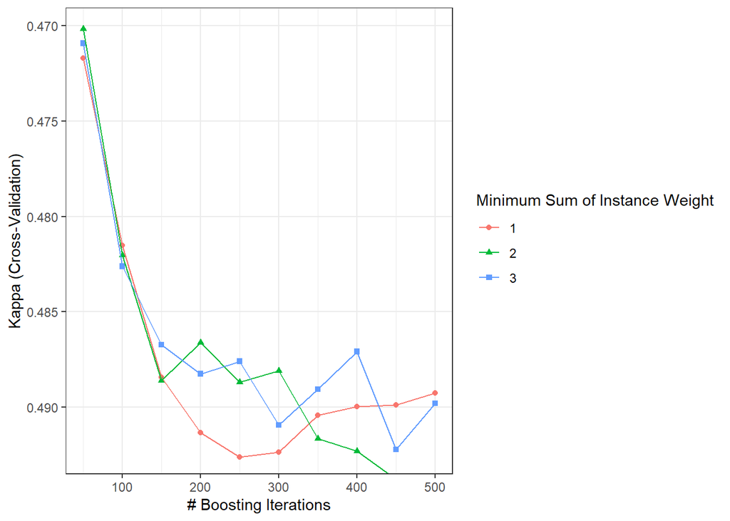

```r
tuneplot(xgbDARTtuningmodel5classes4)
```

Gamma controls regularization (prevents overfitting). Gamma is minimum loss reduction required to make a further partition on a leaf node of the tree. The larger gamma is, the more conservative the algorithm will be.The main consequence of using a gamma different from 0 is to stop the algorithm from growing useless trees that barely reduce the in-sample error and are likely to result in over-fitting

```r
set.seed(42)

XGBoostgrid5 <- expand.grid(
  nrounds = seq(from = 50, to = 500, by = 50),
  eta = xgbDARTtuningmodel5classes$bestTune$eta,
  max_depth = xgbDARTtuningmodel5classes2$bestTune$max_depth,
  gamma = c(0, 0.1, 0.25, 0.5, 0.75, 1.0),
  colsample_bytree = xgbDARTtuningmodel5classes3$bestTune$colsample_bytree,
  min_child_weight = xgbDARTtuningmodel5classes4$bestTune$min_child_weight,
  rate_drop = xgbDARTtuningmodel5classes2$bestTune$rate_drop,
  skip_drop = xgbDARTtuningmodel5classes2$bestTune$skip_drop,
  subsample = xgbDARTtuningmodel5classes3$bestTune$subsample)

xgbDARTtuningmodel5classes5 <- caret::train(quinaryMoisture~., data = quinarytrainingData, trControl = tune_control, tuneGrid = XGBoostgrid5, method = "xgbDART",verbose = TRUE, metric="Kappa")
xgbDARTtuningmodel5classes5$bestTune
```

```
##    nrounds max_depth eta gamma subsample colsample_bytree rate_drop skip_drop
## 16     300         5 0.1   0.1       0.5              0.5      0.25       0.5
##    min_child_weight
## 16                2
```

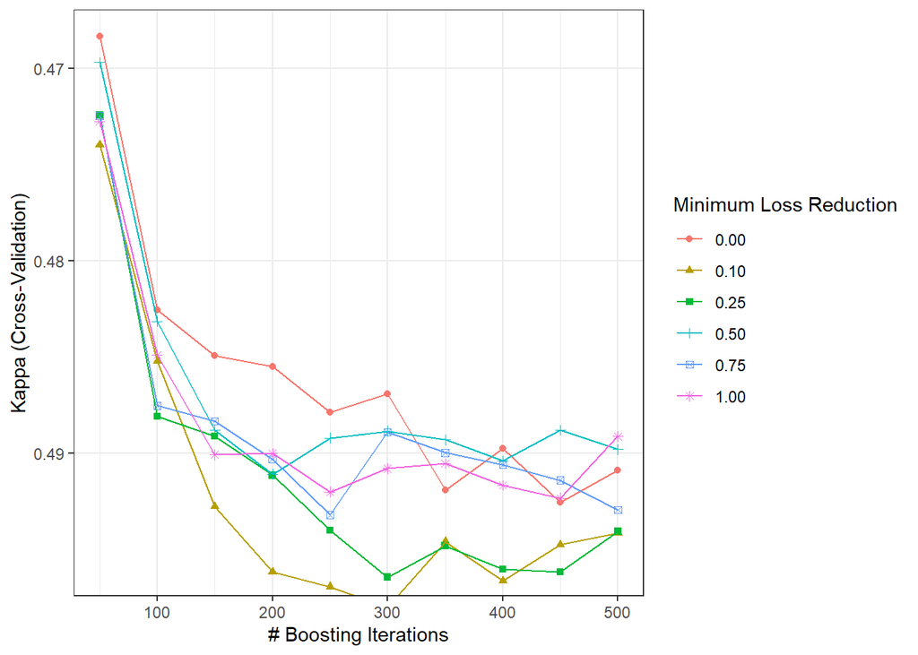

```r
tuneplot(xgbDARTtuningmodel5classes5)
```

Now we will fix all hyperparamters and train that model on all trainingdata and then test it on the test data.

```r
Final_control <- caret::trainControl(method = "none", verboseIter = FALSE)

XGBoostgrid6 <- expand.grid(
  nrounds = xgbDARTtuningmodel5classes5$bestTune$nrounds,
  eta = xgbDARTtuningmodel5classes5$bestTune$eta,
  max_depth = xgbDARTtuningmodel5classes5$bestTune$max_depth,
  gamma = xgbDARTtuningmodel5classes5$bestTune$gamma,
  colsample_bytree = xgbDARTtuningmodel5classes5$bestTune$colsample_bytree,
  min_child_weight = xgbDARTtuningmodel5classes5$bestTune$min_child_weight,
  rate_drop = xgbDARTtuningmodel5classes5$bestTune$rate_drop,
  skip_drop = xgbDARTtuningmodel5classes5$bestTune$skip_drop,
  subsample = xgbDARTtuningmodel5classes3$bestTune$subsample)

xgbDARTtuningmodel5classes6 <- caret::train(quinaryMoisture~., data = quinarytrainingData, trControl = Final_control, tuneGrid = XGBoostgrid6, method = "xgbDART",verbose = TRUE, metric="Kappa")
xgbDARTtuningmodel5classes6$bestTune
```

```
##   nrounds eta max_depth gamma colsample_bytree min_child_weight rate_drop
## 1     300 0.1         5   0.1              0.5                2      0.25
##   skip_drop subsample
## 1       0.5       0.5
```

```r
XGBOOSTPredictions <-predict(xgbDARTtuningmodel5classes6, quinarytestData,ntree_limit=nrounds)
cmXGBOOST <-confusionMatrix(XGBOOSTPredictions, quinarytestData$quinaryMoisture)
print(cmXGBOOST)
```

```
## Confusion Matrix and Statistics
##
##           Reference
## Prediction    1    2    3    4    5
##          1   42   38    0    0    0
##          2  174 1934  328   17    0
##          3    4  205  636  170   17
##          4    0    5   85  177   44
##          5    0    0    4   18   29
##
## Overall Statistics
##
##                Accuracy : 0.7176
##                  95% CI : (0.7032, 0.7316)
##     No Information Rate : 0.5556
##     P-Value [Acc > NIR] : < 2.2e-16
##
##                   Kappa : 0.5074
##
##  Mcnemar's Test P-Value : NA
##
## Statistics by Class:
##
##                      Class: 1 Class: 2 Class: 3 Class: 4 Class: 5
## Sensitivity           0.19091   0.8863   0.6040  0.46335 0.322222
## Specificity           0.98975   0.7026   0.8622  0.96220 0.994266
## Pos Pred Value        0.52500   0.7884   0.6163  0.56913 0.568627
## Neg Pred Value        0.95373   0.8318   0.8560  0.94331 0.984262
## Prevalence            0.05602   0.5556   0.2681  0.09728 0.022918
## Detection Rate        0.01070   0.4925   0.1620  0.04507 0.007385
## Detection Prevalence  0.02037   0.6246   0.2628  0.07920 0.012987
## Balanced Accuracy     0.59033   0.7945   0.7331  0.71278 0.658244
```

```r
XGBoosttable<-cmXGBOOST$byClass
XGBoosttable
```

```
##          Sensitivity Specificity Pos Pred Value Neg Pred Value Precision
## Class: 1   0.1909091   0.9897491      0.5250000      0.9537302 0.5250000
## Class: 2   0.8863428   0.7025788      0.7884223      0.8317503 0.7884223
## Class: 3   0.6039886   0.8622129      0.6162791      0.8559585 0.6162791
## Class: 4   0.4633508   0.9622003      0.5691318      0.9433075 0.5691318
## Class: 5   0.3222222   0.9942664      0.5686275      0.9842621 0.5686275
##             Recall        F1 Prevalence Detection Rate Detection Prevalence
## Class: 1 0.1909091 0.2800000 0.05602241    0.010695187           0.02037179
## Class: 2 0.8863428 0.8345200 0.55564044    0.492487904           0.62464986
## Class: 3 0.6039886 0.6100719 0.26814362    0.161955691           0.26279603
## Class: 4 0.4633508 0.5108225 0.09727527    0.045072574           0.07919531
## Class: 5 0.3222222 0.4113475 0.02291826    0.007384772           0.01298701
##          Balanced Accuracy
## Class: 1         0.5903291
## Class: 2         0.7944608
## Class: 3         0.7331008
## Class: 4         0.7127755
## Class: 5         0.6582443
```

```r
ImportantVariables<-varImp(xgbDARTtuningmodel5classes6, scale = FALSE)
importanceplot<-ggplot(ImportantVariables, top = 23) + theme_bw() + theme(panel.border = element_blank(), panel.grid.major = element_blank(), panel.grid.minor = element_blank(), axis.line = element_line(colour = "black"))
ggsave(importanceplot, file = "V:/XGBoostArticle/importanceplot5classes.png", dpi = 600)
```

When we put the model into production we will use all data to train the model without resampling. Both the training data and the testing data.

```r
set.seed(42)

Final_control <- caret::trainControl(method = "none", verboseIter = FALSE)
Final_grid <- expand.grid(
  nrounds = xgbDARTtuningmodel5classes6$bestTune$nrounds,
  eta = xgbDARTtuningmodel5classes6$bestTune$eta,
  max_depth = xgbDARTtuningmodel5classes6$bestTune$max_depth,
  gamma = xgbDARTtuningmodel5classes6$bestTune$gamma,
  colsample_bytree = xgbDARTtuningmodel5classes6$bestTune$colsample_bytree,
  min_child_weight = xgbDARTtuningmodel5classes6$bestTune$min_child_weight,
  rate_drop = xgbDARTtuningmodel5classes6$bestTune$rate_drop,
  skip_drop = xgbDARTtuningmodel5classes6$bestTune$skip_drop,
  subsample = xgbDARTtuningmodel5classes6$bestTune$subsample
)

xgbDARTtuningmodel_PredictModel <- caret::train(quinaryMoisture~., data = quinarydataset, trControl = Final_control, tuneGrid = Final_grid, method = "xgbDART",verbose = TRUE, metric="Kappa")
```

Save the trained model for later use

```r
saveRDS(xgbDARTtuningmodel_PredictModel, "V:/MLWAM_Production/SavedModel/MLWAM5Classes.rds")
```